# Cruise Report for DY15-05

## Cruise Report for DY15-05

### Quick Cruise FastCAT Summary

During the cruise DY15-05 there were 10 tows with depth, temperature, and salinity collected. Tows were taken from May 15 to May 24 of 2015. Temperature ranged from 5.2 to 6.7 with a mean of 5.8 Celcius. Salinity ranged from 29.1 to 32.2 with a mean of 31.79 PSU. The deepest tow was 103. The Southern most tow was 54.96 and the furthest North was 56.88 Latitude. The Western most tow was -159.85 and the Eastern most was -156.51 Longitude.

### Average Salinity and Temperature Profiles

Plot shows average salinity and temperature (point) and 95% Confidence Intervals for each integer of depth.

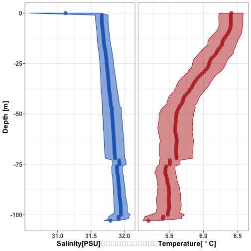

### Station Map

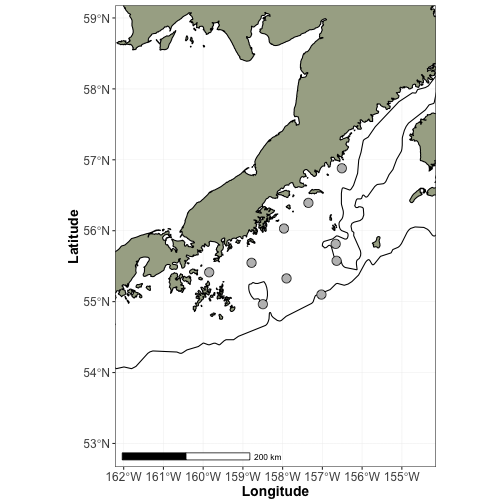

If any of this looks suspect, check for the values in the .csv file and then correct in MasterCOD. After this is done, re-run the Perl script and then re-run FastrCAT.

### Summary Statistics

```
##       LAT             LON          DEPTH_BOTTOM       DEPTH
##  Min.   :54.96   Min.   :-159.8   Min.   : 57.0   Min.   :  0.0
##  Median :55.55   Median :-157.9   Median :153.0   Median : 45.0
##  Mean   :55.64   Mean   :-157.8   Mean   :157.8   Mean   : 46.9
##  Max.   :56.88   Max.   :-156.5   Max.   :248.0   Max.   :103.0
##     PRESSURE      TEMPERATURE1     SALINITY1     CONDUCTIVITY1
##  Min.   :  1.0   Min.   :5.155   Min.   :29.14   Min.   :29.48
##  Median : 46.0   Median :5.732   Median :31.80   Median :31.42
##  Mean   : 47.9   Mean   :5.827   Mean   :31.79   Mean   :31.39
##  Max.   :104.0   Max.   :6.724   Max.   :32.19   Max.   :32.16
##     SIGMA_T
##  Min.   :22.87
##  Median :25.07
##  Mean   :25.04
##  Max.   :25.35
```

**List of Cruise Names** If there is more than one Cruise name, please fix in MasterCOD.

```
## [1] "DY15-05"
```

**List of Station.hauls**

```
##  [1] "1.2"   "10.1"  "20.1"  "30.1"  "41.1"  "50.1"  "60.1"  "70.1"
##  [9] "80.1"  "100.1"
```

**List of FOCI grid names**

```
## [1] "GR135" NA
```

### Anomalous Salinity and Temperature

These values for salinity and temperature are outside of known ranges. They have been filtered out of the data, because they are outside the know ranges for salinity and temperature. NA's refer to no outlier values found either below the minimum cutoff or above the maximum cutoff. If there is no data below, then all readings were within known ranges.

```
## [1] CRUISE       STATION_NAME HAUL_NAME    FOCI_GRID    Min_value
## [6] Max_value    ERROR_TYPE
## <0 rows> (or 0-length row.names)
```

### No Header Files

These files have been identified as having no header information. It is most likely that you ran the Perl script prior to entering the station COD form into MasterCOD. Please re-run Perl script and then make_dataframe_fc() after you have checked that you enterd the COD form. If there is not anything below then all header information was present.

```
## data frame with 0 columns and 0 rows
```

### No Data Files

Below are files which were identified as having no data. Make sure that this is true. Since all casts are processed by the perl script and the make_dataframe_fc() regardless if they were Good, Questionable, or “Failure. If there is not a dataframe below then all files contained data.

```
## data frame with 0 columns and 0 rows
```